# Einführung in die Datenanalyse mit R: Analyse der Nettozuwanderung in die Schweiz

Vollständiger Code

Autor:in

Vincent Pickert - 2020-061-610

Veröffentlichungsdatum

9. Juni 2026

**Hinweis**

**Hinweis zur Version:** Dies ist die vollständige Code-Version der Analyse. Alle Code-Blöcke sind sichtbar und können über die Schaltfläche „Code anzeigen” ein- und ausgeklappt werden.

# Reproduzierbarkeits-Prüfung

Beim Start des Skripts wird geprüft, ob die installierten Paketversionen mit der Entwicklungsumgebung übereinstimmen. Bei Abweichungen erscheint eine Warnung.

**Code anzeigen**

```r
erforderliche_versionen <- list(
  readr         = "2.2.0",
  dplyr         = "1.2.1",
  stringr       = "1.6.0",
  stringi       = "1.8.7",
  tibble        = "3.3.1",
  tidyr         = "1.3.2",
  ggplot2       = "4.0.3",
  scales        = "1.4.0",
  sf            = "1.1.1",
  WDI           = "2.7.10",
  rnaturalearth = "1.2.0",
  countrycode   = "1.8.0",
  rvest         = "1.0.5",
  huxtable      = "5.8.0",
  stargazer     = "5.2.3",
  texreg        = "1.39.5",
  broom         = "1.0.13",
  codetools     = "0.2.20",
  gtsummary     = "2.5.1",
  gt            = "1.3.0"
)

version_mismatches <- list()

for (pkg in names(erforderliche_versionen)) {
  if (!requireNamespace(pkg, quietly = TRUE)) {
    stop(paste0("FEHLER: Paket '", pkg, "' ist nicht installiert!"))
  }
  aktuelle_version   <- as.character(packageVersion(pkg))
  benoetigte_version <- erforderliche_versionen[[pkg]]
  if (aktuelle_version != benoetigte_version) {
    version_mismatches[[pkg]] <- list(
      aktuell   = aktuelle_version,
      benoetigt = benoetigte_version
    )
  }
}

if (length(version_mismatches) > 0) {
  msgs <- vapply(names(version_mismatches), function(pkg) {
    paste0(pkg, ": installiert ", version_mismatches[[pkg]]$aktuell,
           ", Entwicklung nutzte ", version_mismatches[[pkg]]$benoetigt)
  }, character(1))
  warning("Paketversionen weichen ab:\n", paste(msgs, collapse = "\n"))
} else {
  cat("✓ Alle Paketversionen entsprechen der Entwicklungsumgebung.\n")
}
```

```
✓ Alle Paketversionen entsprechen der Entwicklungsumgebung.
```

# Setup und Pakete

Alle benötigten Pakete werden geladen. Fehlende Pakete werden automatisch installiert. Die Ausgabe-Ordner `tabellen`, `grafiken` und `data` werden neben dem Skript erstellt, falls sie noch nicht existieren.

**Code anzeigen**

```r
erforderliche_pakete <- c(
  "readr", "dplyr", "stringr", "stringi", "ggplot2", "WDI",
  "rnaturalearth", "countrycode", "huxtable", "scales", "sf",
  "tibble", "broom", "stargazer", "texreg", "tidyr", "codetools",
  "rvest", "gtsummary", "gt"
)

options(scipen = 999)
options(repos = c(CRAN = "https://cloud.r-project.org"))

fehlende_pakete <- setdiff(erforderliche_pakete, rownames(installed.packages()))
if (length(fehlende_pakete) > 0) {
  install.packages(fehlende_pakete)
}

invisible(lapply(erforderliche_pakete, library, character.only = TRUE))

pfade <- c("tabellen", "grafiken", "data")
invisible(lapply(pfade, function(pfad) {
  if (!dir.exists(pfad)) dir.create(pfad, recursive = TRUE)
}))

cat("Arbeitsverzeichnis:", getwd(), "\n")
```

```
Arbeitsverzeichnis: /Users/vfp/kDrive/Uni Bern/Einführung in die Datenanalyse mit R/Positron/Datenanalyse
```

**Code anzeigen**

```r
cat("Ordner erstellt / vorhanden:", paste(pfade, collapse = ", "), "\n")
```

```
Ordner erstellt / vorhanden: tabellen, grafiken, data
```

# Daten importieren und aufbereiten

## Schweizerische Einwanderungsdaten

Die Einwanderungsdaten wurden von der Bundesamt für Statistik-Webseite heruntergeladen. Sie enthalten die Nettozuwanderung nach Herkunftsland und Jahr (1991–2024). Das Skript lädt die Datei lokal, falls vorhanden, ansonsten direkt von GitHub.

**Code anzeigen**

```r
if (file.exists("data/swiss_immigration_countries_year.csv")) {
  rohe_schweizer_einwanderung <- readr::read_csv(
    "data/swiss_immigration_countries_year.csv",
    show_col_types = FALSE
  )
} else {
  rohe_schweizer_einwanderung <- readr::read_csv(
    "https://raw.githubusercontent.com/Gabendd/datenanalyse/main/data/swiss_immigration_countries_year.csv",
    show_col_types = FALSE
  )
}

rohe_schweizer_einwanderung <- rohe_schweizer_einwanderung |>
  dplyr::mutate(
    jahr              = as.integer(year),
    netto_zuwanderung = as.numeric(net_migration)
  ) |>
  dplyr::rename(herkunft = origin_en) |>
  dplyr::filter(
    !herkunft %in% c(
      "Afrique", "Amérique", "Asie", "Océanie",
      "EFTA countries", "Yugoslavia", "Serbia and Montenegro"
    ),
    !stringr::str_detect(herkunft, "Renseignements|Source|© OFS")
  ) |>
  dplyr::select(herkunft, jahr, netto_zuwanderung) |>
  dplyr::arrange(herkunft, jahr)

cat("Importierte Zeilen:", nrow(rohe_schweizer_einwanderung), "\n")
```

```
Importierte Zeilen: 510
```

**Code anzeigen**

```r
cat("Herkunftsländer:  ", n_distinct(rohe_schweizer_einwanderung$herkunft), "\n")
```

```
Herkunftsländer:   15
```

**Code anzeigen**

```r
cat("Zeitraum:         ", min(rohe_schweizer_einwanderung$jahr),
    "–", max(rohe_schweizer_einwanderung$jahr), "\n")
```

```
Zeitraum:          1991 – 2024
```

Anschliessend werden die Daten auf Jahresbasis aggregiert:

**Code anzeigen**

```r
jahresdaten_schweizer_einwanderung <- rohe_schweizer_einwanderung |>
  dplyr::group_by(jahr) |>
  dplyr::summarize(
    netto_zuwanderung = sum(netto_zuwanderung, na.rm = TRUE),
    .groups = "drop"
  ) |>
  dplyr::arrange(jahr)

summary(jahresdaten_schweizer_einwanderung$netto_zuwanderung)
```

```
   Min. 1st Qu.  Median    Mean 3rd Qu.    Max.
 -10589   12555   26290   27759   45763   70558
```

Das Minimum von −10’589 zeigt, dass es Jahre gab, in denen die Schweiz mehr Auswanderungen als Einwanderungen verzeichnete. Der Median (26’290) liegt unter dem Mittelwert (27’759), was auf einzelne Jahre mit besonders hoher Zuwanderung hindeutet.

## World Bank Indikatoren

Als unabhängige Variable wird das BIP-Wachstum (jährlich in %) und als Kontrollvariable die Arbeitslosenquote verwendet. Beide werden über die World Bank API bezogen und lokal gecacht.

**Code anzeigen**

```r
indikatoren_liste <- tibble::tibble(
  Code = c("NY.GDP.MKTP.KD.ZG", "SL.UEM.TOTL.ZS"),
  Description = c(
    "BIP-Wachstum (jährlich in %)",
    "Arbeitslosigkeit, insgesamt (% der Erwerbsbevölkerung)"
  )
)

indikatoren <- indikatoren_liste$Code

weltbank_datei_pfad <- "data/world_bank_raw.rds"
start_jahr <- min(jahresdaten_schweizer_einwanderung$jahr, na.rm = TRUE)
end_jahr   <- max(jahresdaten_schweizer_einwanderung$jahr, na.rm = TRUE)

weltbank_daten_abrufen <- function() {
  WDI::WDI(
    country   = "CHE",
    indicator = indikatoren,
    start     = start_jahr,
    end       = end_jahr,
    extra     = TRUE
  )
}

if (!file.exists(weltbank_datei_pfad)) {
  weltbank_rohe_daten <- weltbank_daten_abrufen()
  saveRDS(weltbank_rohe_daten, weltbank_datei_pfad)
} else {
  temp_pruefung    <- readRDS(weltbank_datei_pfad)
  fehlend_in_datei <- setdiff(indikatoren, names(temp_pruefung))
  if (length(fehlend_in_datei) > 0) {
    weltbank_rohe_daten <- weltbank_daten_abrufen()
    saveRDS(weltbank_rohe_daten, weltbank_datei_pfad)
  } else {
    weltbank_rohe_daten <- temp_pruefung
  }
  rm(temp_pruefung, fehlend_in_datei)
}

schweizer_weltbank_daten <- weltbank_rohe_daten |>
  dplyr::select(year, dplyr::all_of(indikatoren)) |>
  dplyr::rename(
    jahr              = year,
    bip_wachstum      = NY.GDP.MKTP.KD.ZG,
    arbeitslosenquote = SL.UEM.TOTL.ZS
  ) |>
  dplyr::arrange(jahr)

cat("World Bank Daten geladen. Zeitraum:",
    min(schweizer_weltbank_daten$jahr), "–",
    max(schweizer_weltbank_daten$jahr),
    "| Zeilen:", nrow(schweizer_weltbank_daten), "\n")
```

```
World Bank Daten geladen. Zeitraum: 1991 – 2024 | Zeilen: 34
```

## Zusammengeführte Analysedaten

**Code anzeigen**

```r
analysedaten_schweiz <- jahresdaten_schweizer_einwanderung |>
  dplyr::left_join(schweizer_weltbank_daten, by = "jahr") |>
  dplyr::arrange(jahr)

cat("NA-Werte pro Variable:\n")
```

```
NA-Werte pro Variable:
```

**Code anzeigen**

```r
print(colSums(is.na(analysedaten_schweiz)))
```

```
             jahr netto_zuwanderung      bip_wachstum arbeitslosenquote
                0                 0                 0                 0
```

Es sind keine fehlenden Werte vorhanden — der Datensatz ist vollständig.

# Weltkarte der Nettozuwanderung

Die Karte zeigt die kumulierte Nettozuwanderung in die Schweiz nach europäischem Herkunftsland (1991–2024).

**Code anzeigen**

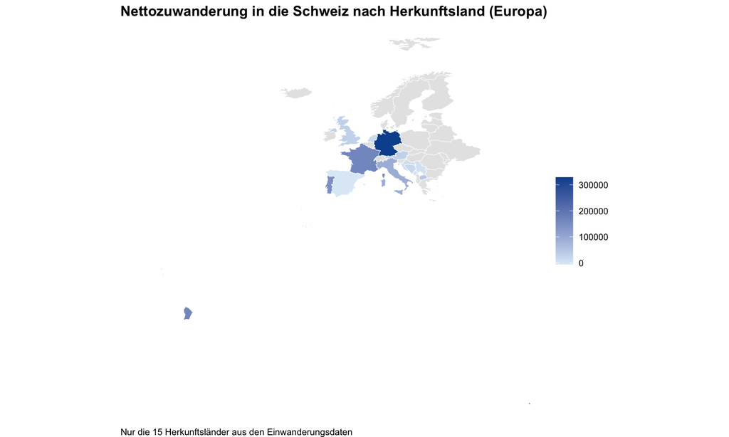

```r
welt <- rnaturalearth::ne_countries(scale = "medium", returnclass = "sf")

karten_daten <- rohe_schweizer_einwanderung |>
  dplyr::group_by(herkunft) |>
  dplyr::summarise(
    netto_zuwanderung = sum(netto_zuwanderung, na.rm = TRUE),
    .groups = "drop"
  ) |>
  dplyr::mutate(
    iso_a3 = countrycode::countrycode(
      herkunft,
      origin      = "country.name",
      destination = "iso3c"
    )
  ) |>
  dplyr::filter(!is.na(iso_a3))

weltkarte <- welt |>
  dplyr::mutate(iso_a3 = dplyr::coalesce(iso_a3_eh, iso_a3)) |>
  dplyr::filter(
    continent  == "Europe",
    !name_long %in% c("Russian Federation"),
    !is.na(iso_a3),
    iso_a3     != "-99"
  ) |>
  dplyr::left_join(karten_daten, by = "iso_a3")

schweiz_migrations_weltkarte <- ggplot2::ggplot(weltkarte) +
  ggplot2::geom_sf(
    ggplot2::aes(fill = netto_zuwanderung),
    color = "white", linewidth = 0.2
  ) +
  ggplot2::scale_fill_gradient(
    low      = "#deebf7",
    high     = "#08519c",
    na.value = "grey90"
  ) +
  ggplot2::labs(
    title   = "Nettozuwanderung in die Schweiz nach Herkunftsland (Europa)",
    fill    = "",
    caption = "Nur die 15 Herkunftsländer aus den Einwanderungsdaten"
  ) +
  ggplot2::theme_void() +
  ggplot2::theme(
    plot.title   = ggplot2::element_text(face = "bold", size = 14),
    legend.title = ggplot2::element_blank(),
    plot.caption = ggplot2::element_text(size = 9, hjust = 0)
  )

schweiz_migrations_weltkarte
```

**Code anzeigen**

```r
ggplot2::ggsave(
  file.path("grafiken", "schweiz_migrations_weltkarte.png"),
  plot = schweiz_migrations_weltkarte, width = 10, height = 6, dpi = 300
)
```

Deutschland und Frankreich dominieren als wichtigste Herkunftsländer. Spanien weist über den gesamten Zeitraum eine negative Nettozuwanderung auf — eine mögliche Erklärung ist, dass Spanier nach der Pensionierung in ihre Heimat zurückziehen.

# Visualisierungen

## Nettozuwanderung über die Zeit

**Code anzeigen**

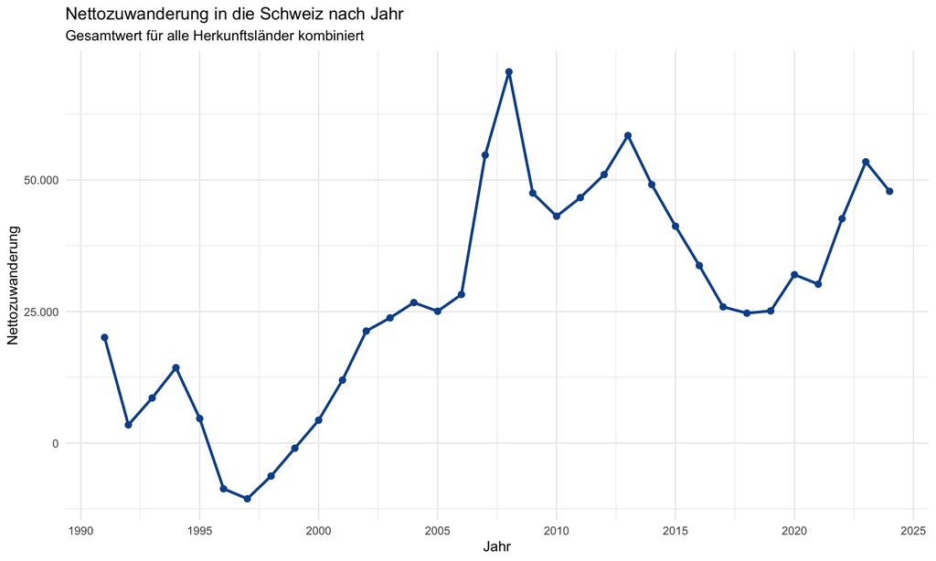

```r
kurven_diagramm <- ggplot(
  jahresdaten_schweizer_einwanderung,
  aes(x = jahr, y = netto_zuwanderung)
) +
  geom_line(color = "#08519c", linewidth = 1) +
  geom_point(color = "#08519c", size = 2) +
  labs(
    x        = "Jahr",
    y        = "Nettozuwanderung",
    title    = "Nettozuwanderung in die Schweiz nach Jahr",
    subtitle = "Gesamtwert für alle Herkunftsländer kombiniert"
  ) +
  theme_minimal() +
  scale_x_continuous(breaks = seq(1990, 2025, by = 5)) +
  scale_y_continuous(
    labels = scales::comma_format(big.mark = ".", decimal.mark = ",")
  )

kurven_diagramm
```

**Code anzeigen**

```r
ggplot2::ggsave(
  file.path("grafiken", "kurven_diagramm.png"),
  plot = kurven_diagramm, width = 10, height = 6, dpi = 300
)
```

Nach einer Auswanderungsphase zwischen 1995 und 2000 stieg die Nettozuwanderung ab 2000 stark an. Die Finanzkrise 2008 führte zu einem vorübergehenden Einbruch, danach folgte erneutes Wachstum bis ca. 2014.

## Boxplot nach Vorzeichen

**Code anzeigen**

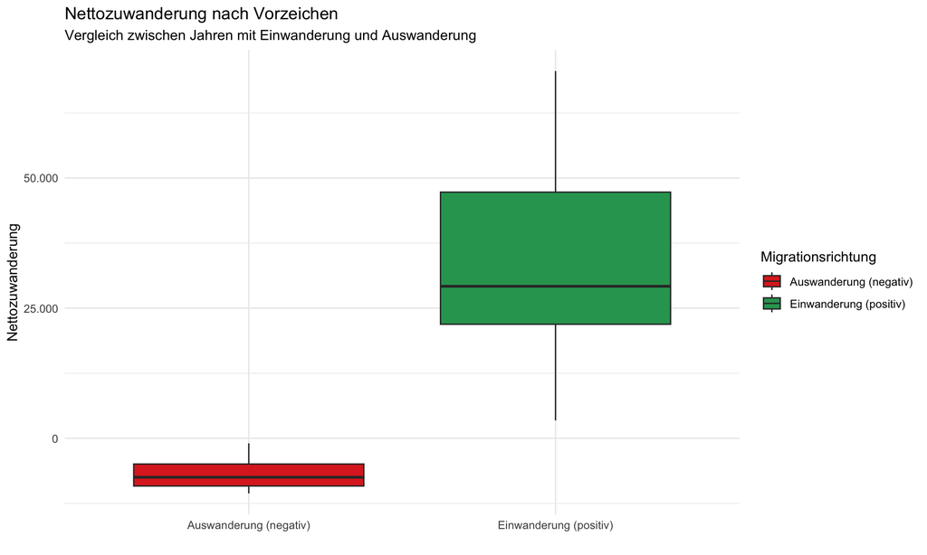

```r
jahresdaten_mit_vorzeichen <- jahresdaten_schweizer_einwanderung |>
  dplyr::mutate(
    migration_sign = ifelse(
      netto_zuwanderung >= 0,
      "Einwanderung (positiv)",
      "Auswanderung (negativ)"
    )
  )

boxplot_vorzeichen <- ggplot(
  jahresdaten_mit_vorzeichen,
  aes(x = migration_sign, y = netto_zuwanderung, fill = migration_sign)
) +
  geom_boxplot() +
  scale_fill_manual(
    values = c(
      "Einwanderung (positiv)" = "#2ca25f",
      "Auswanderung (negativ)" = "#de2d26"
    ),
    name = "Migrationsrichtung"
  ) +
  labs(
    x        = "",
    y        = "Nettozuwanderung",
    title    = "Nettozuwanderung nach Vorzeichen",
    subtitle = "Vergleich zwischen Jahren mit Einwanderung und Auswanderung"
  ) +
  theme_minimal() +
  scale_y_continuous(
    labels = scales::comma_format(big.mark = ".", decimal.mark = ",")
  )

boxplot_vorzeichen
```

**Code anzeigen**

```r
ggplot2::ggsave(
  file.path("grafiken", "boxplot_vorzeichen.png"),
  plot = boxplot_vorzeichen, width = 10, height = 6, dpi = 300
)
```

**Code anzeigen**

```r
zusammenfassung <- jahresdaten_mit_vorzeichen |>
  dplyr::group_by(migration_sign) |>
  dplyr::summarize(
    Anzahl     = n(),
    Mittelwert = mean(netto_zuwanderung),
    Median     = median(netto_zuwanderung),
    SD         = sd(netto_zuwanderung),
    Min        = min(netto_zuwanderung),
    Max        = max(netto_zuwanderung),
    IQR        = IQR(netto_zuwanderung)
  )

knitr::kable(zusammenfassung, digits = 0,
             format.args = list(big.mark = "'"),
             caption = "Deskriptive Statistik nach Migrationsrichtung")
```

Deskriptive Statistik nach Migrationsrichtung

| migration_sign | Anzahl | Mittelwert | Median | SD | Min | Max | IQR |
| --- | --- | --- | --- | --- | --- | --- | --- |
| Auswanderung (negativ) | 4 | -6’629 | -7’478 | 4’167 | -10’589 | -970 | 4’220 |
| Einwanderung (positiv) | 30 | 32’344 | 29’210 | 17’609 | 3’446 | 70’558 | 25’377 |

## Nettozuwanderung nach Herkunftsland

**Code anzeigen**

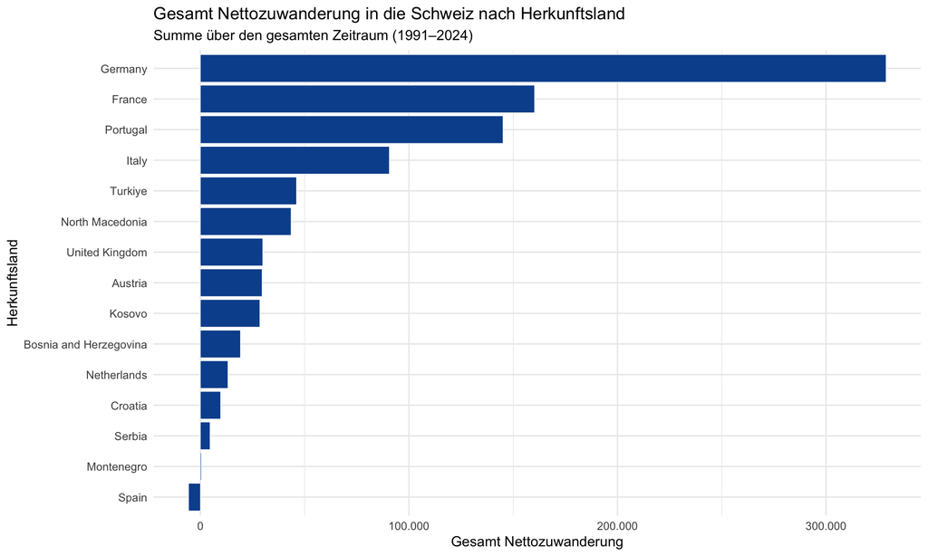

```r
laender_gesamt <- rohe_schweizer_einwanderung |>
  dplyr::group_by(herkunft) |>
  dplyr::summarise(
    gesamt_netto_zuwanderung = sum(netto_zuwanderung, na.rm = TRUE),
    .groups = "drop"
  ) |>
  dplyr::arrange(desc(gesamt_netto_zuwanderung))

horizontales_balkendiagramm <- ggplot(
  laender_gesamt,
  aes(
    x = gesamt_netto_zuwanderung,
    y = reorder(herkunft, gesamt_netto_zuwanderung)
  )
) +
  geom_col(fill = "#08519c", color = "white", linewidth = 0.2) +
  labs(
    x        = "Gesamt Nettozuwanderung",
    y        = "Herkunftsland",
    title    = "Gesamt Nettozuwanderung in die Schweiz nach Herkunftsland",
    subtitle = "Summe über den gesamten Zeitraum (1991–2024)"
  ) +
  theme_minimal() +
  scale_x_continuous(
    labels = scales::comma_format(big.mark = ".", decimal.mark = ",")
  )

horizontales_balkendiagramm
```

**Code anzeigen**

```r
ggplot2::ggsave(
  file.path("grafiken", "horizontales_balkendiagramm.png"),
  plot = horizontales_balkendiagramm, width = 10, height = 6, dpi = 300
)
```

Portugal übertrifft Italien, was möglicherweise damit zusammenhängt, dass viele Grenzgänger aus Italien ihren Wohnsitz in Italien behalten und daher nicht als Einwanderer gezählt werden.

# Regressionsmodelle

Es werden zwei OLS-Modelle geschätzt. Die abhängige Variable ist in beiden Fällen die Nettozuwanderung auf Jahresbasis.

- **Modell 1:** Nur BIP-Wachstum als Prädiktor
- **Modell 2:** BIP-Wachstum + Arbeitslosenquote als Kontrollvariable

**Code anzeigen**

```r
regressionsdaten <- analysedaten_schweiz |>
  dplyr::select(netto_zuwanderung, bip_wachstum, arbeitslosenquote)

readr::write_csv(regressionsdaten, "data/regressionsdaten.csv")

cat("Beobachtungen:", nrow(regressionsdaten), "\n")
```

```
Beobachtungen: 34
```

**Code anzeigen**

```r
modell_1_bip <- lm(
  netto_zuwanderung ~ bip_wachstum,
  data = regressionsdaten
)

modell_2_bip_arbeitslosenquote <- lm(
  netto_zuwanderung ~ bip_wachstum + arbeitslosenquote,
  data = regressionsdaten
)

summary(modell_1_bip)
```

```
Call:
lm(formula = netto_zuwanderung ~ bip_wachstum, data = regressionsdaten)

Residuals:
   Min     1Q Median     3Q    Max
-39084 -15054  -2108  17374  41428

Coefficients:
             Estimate Std. Error t value  Pr(>|t|)
(Intercept)     25865       5031   5.142 0.0000132 ***
bip_wachstum     1163       2143   0.542     0.591
---
Signif. codes:  0 '***' 0.001 '**' 0.01 '*' 0.05 '.' 0.1 ' ' 1

Residual standard error: 21120 on 32 degrees of freedom
Multiple R-squared:  0.009111,  Adjusted R-squared:  -0.02185
F-statistic: 0.2942 on 1 and 32 DF,  p-value: 0.5913
```

**Code anzeigen**

```r
summary(modell_2_bip_arbeitslosenquote)
```

```
Call:
lm(formula = netto_zuwanderung ~ bip_wachstum + arbeitslosenquote,
    data = regressionsdaten)

Residuals:
   Min     1Q Median     3Q    Max
-40372  -9325  -5280  13378  49975

Coefficients:
                  Estimate Std. Error t value Pr(>|t|)
(Intercept)       -18119.4    16129.4  -1.123  0.26990
bip_wachstum        -186.9     1996.8  -0.094  0.92604
arbeitslosenquote  11709.4     4119.3   2.843  0.00785 **
---
Signif. codes:  0 '***' 0.001 '**' 0.01 '*' 0.05 '.' 0.1 ' ' 1

Residual standard error: 19110 on 31 degrees of freedom
Multiple R-squared:  0.214, Adjusted R-squared:  0.1633
F-statistic:  4.22 on 2 and 31 DF,  p-value: 0.02394
```

**Code anzeigen**

```r
texreg::htmlreg(
  list(Modell_1 = modell_1_bip, Modell_2 = modell_2_bip_arbeitslosenquote),
  custom.model.names = c("Modell 1", "Modell 2"),
  custom.coef.names  = c("(Intercept)", "BIP-Wachstum", "Arbeitslosenquote"),
  custom.note        = "Abhängige Variable: Nettozuwanderung. Signifikanz: * p < 0.05, ** p < 0.01, *** p < 0.001",
  digits             = 5,
  single.row         = FALSE,
  include.f          = TRUE,
  caption            = "Regressionsergebnisse: Nettozuwanderung"
)
```

Regressionsergebnisse: Nettozuwanderung

|  | Modell 1 | Modell 2 |
| --- | --- | --- |
| (Intercept) | 25865.41246*** | -18119.40583 |
|  | (5030.56083) | (16129.42897) |
| BIP-Wachstum | 1162.63426 | -186.86383 |
|  | (2143.42466) | (1996.82775) |
| Arbeitslosenquote |  | 11709.43936** |
|  |  | (4119.34949) |
| R<sup>2</sup> | 0.00911 | 0.21398 |
| Adj. R<sup>2</sup> | -0.02185 | 0.16327 |
| Num. obs. | 34 | 34 |
| F statistic | 0.29422 | 4.21969 |

Abhängige Variable: Nettozuwanderung. Signifikanz: * p < 0.05, ** p < 0.01, *** p < 0.001

**Code anzeigen**

```r
texreg::htmlreg(
  list(Modell_1 = modell_1_bip, Modell_2 = modell_2_bip_arbeitslosenquote),
  file               = file.path("tabellen", "regressionsergebnisse_texreg.html"),
  custom.model.names = c("Modell 1", "Modell 2"),
  custom.coef.names  = c("(Intercept)", "BIP-Wachstum", "Arbeitslosenquote"),
  custom.note        = "Abhängige Variable: Nettozuwanderung. Signifikanz: * p < 0.05, ** p < 0.01, *** p < 0.001",
  digits             = 5,
  single.row         = FALSE,
  include.f          = TRUE,
  caption            = "Regressionsergebnisse: Nettozuwanderung"
)
```

```
The table was written to the file 'tabellen/regressionsergebnisse_texreg.html'.
```

**Modell 1:** Ein Anstieg des BIP-Wachstums um 1 Prozentpunkt ist mit ca. 1’163 zusätzlichen Einwanderern verbunden, jedoch statistisch nicht signifikant (p > 0.05). R² = 0.009.

**Modell 2:** Unter Kontrolle der Arbeitslosenquote ist der BIP-Effekt praktisch null (−187 Personen, nicht signifikant). Die Arbeitslosenquote zeigt einen statistisch hoch signifikanten positiven Effekt (+11’709 Personen pro Prozentpunkt, p < 0.01) — ein kontraintuitives Ergebnis, das auf nicht erfasste Drittvariablen hindeutet (z.B. Freizügigkeitsabkommen, Arbeitsmarktlage im Herkunftsland). R² = 0.214.

# Deskriptive Statistik

Die folgende Tabelle vergleicht die zentralen Analysevariablen zwischen Jahren mit positiver und negativer Nettozuwanderung (Einwanderungs- vs. Auswanderungsjahren).

**Code anzeigen**

```r
deskriptive_tabelle <- analysedaten_schweiz |>
  dplyr::mutate(
    migrationsrichtung = ifelse(
      netto_zuwanderung >= 0,
      "Einwanderung",
      "Auswanderung"
    )
  ) |>
  dplyr::select(
    migrationsrichtung,
    netto_zuwanderung,
    bip_wachstum,
    arbeitslosenquote
  ) |>
  gtsummary::tbl_summary(
    by = migrationsrichtung,
    label = list(
      netto_zuwanderung ~ "Nettozuwanderung",
      bip_wachstum      ~ "BIP-Wachstum (%)",
      arbeitslosenquote ~ "Arbeitslosenquote (%)"
    ),
    statistic = list(all_continuous() ~ "{mean} ({sd})"),
    digits    = all_continuous() ~ 2
  ) |>
  gtsummary::modify_header(label = "**Variable**") |>
  gtsummary::bold_labels() |>
  gtsummary::add_p() |>
  gtsummary::as_gt() |>
  gt::tab_header(title = "Deskriptive Statistik nach Migrationsrichtung")

deskriptive_tabelle
```

Deskriptive Statistik nach Migrationsrichtung

| **Variable** | **Auswanderung** N = 4<sup>1</sup> | **Einwanderung** N = 30<sup>1</sup> | **p-value**<sup>2</sup> |
| --- | --- | --- | --- |
| Nettozuwanderung | -6,629.00 (4,166.53) | 32,344.03 (17,609.46) | <0.001 |
| BIP-Wachstum (%) | 1.86 (1.08) | 1.60 (1.79) | 0.8 |
| Arbeitslosenquote (%) | 3.61 (0.44) | 3.99 (0.87) | 0.3 |

<sup>1</sup> Mean (SD)  
<sup>2</sup> Wilcoxon rank sum exact test

# Diagnostische Tests

## Korrelationsmatrix

**Code anzeigen**

```r
korrelationsmatrix <- cor(regressionsdaten)

knitr::kable(
  round(korrelationsmatrix, 3),
  caption = "Korrelationsmatrix der Modellvariablen"
)
```

Korrelationsmatrix der Modellvariablen

|  | netto_zuwanderung | bip_wachstum | arbeitslosenquote |
| --- | --- | --- | --- |
| netto_zuwanderung | 1.000 | 0.095 | 0.462 |
| bip_wachstum | 0.095 | 1.000 | 0.238 |
| arbeitslosenquote | 0.462 | 0.238 | 1.000 |

Der Korrelationswert zwischen BIP-Wachstum und Arbeitslosenquote beträgt r = 0.238 — eine schwache Korrelation, die kein Multikollinearitätsproblem anzeigt.

## Autokorrelation der Residuen

**Code anzeigen**

```r
acf_objekt <- stats::acf(
  residuals(modell_2_bip_arbeitslosenquote),
  plot      = FALSE,
  na.action = na.pass
)

n_beobachtungen <- length(stats::na.omit(
  residuals(modell_2_bip_arbeitslosenquote)
))
konfidenzgrenze <- 1.96 / sqrt(n_beobachtungen)

autokorrelations_daten <- tibble::tibble(
  lag = as.numeric(acf_objekt$lag),
  acf = as.numeric(acf_objekt$acf)
) |>
  dplyr::filter(lag > 0)

knitr::kable(
  head(autokorrelations_daten, 10),
  digits  = 3,
  caption = paste0(
    "ACF der Residuen (95%-Konfidenzgrenze: ±",
    round(konfidenzgrenze, 3), ")"
  )
)
```

ACF der Residuen (95%-Konfidenzgrenze: ±0.336)

| lag | acf |
| --- | --- |
| 1 | 0.739 |
| 2 | 0.380 |
| 3 | 0.213 |
| 4 | 0.144 |
| 5 | 0.074 |
| 6 | 0.029 |
| 7 | -0.041 |
| 8 | -0.150 |
| 9 | -0.235 |
| 10 | -0.292 |

Es zeigt sich starke Autokorrelation bei Lag 1 (0.74) und Lag 2 (0.38), beide über der 95%-Konfidenzgrenze (±0.336). Die Residuen sind zeitlich abhängig — das Modell erfasst die zeitliche Eigendynamik der Nettozuwanderung nicht vollständig, was Standardfehler und Signifikanztests verzerren kann.

# Objekte zusammenfassen

Alle relevanten Objekte werden in thematischen Listen organisiert. Einzelne Objekte werden anschliessend aus dem Arbeitsumfeld entfernt.

**Code anzeigen**

```r
matrix_objekte <- list(
  korrelationsmatrix = korrelationsmatrix,
  acf_objekt         = acf_objekt,
  konfidenzgrenze    = konfidenzgrenze,
  beobachtungen      = n_beobachtungen
)

modell_objekte <- list(
  modell_1_bip                   = modell_1_bip,
  modell_2_bip_arbeitslosenquote = modell_2_bip_arbeitslosenquote
)

plot_objekte <- list(
  weltkarte_migration    = schweiz_migrations_weltkarte,
  verlaufslinie          = kurven_diagramm,
  boxplot_vorzeichen     = boxplot_vorzeichen,
  balkendiagramm_laender = horizontales_balkendiagramm
)

rm(
  welt, weltbank_rohe_daten, indikatoren_liste, indikatoren,
  erforderliche_pakete, fehlende_pakete, pfade, weltbank_datei_pfad,
  start_jahr, end_jahr, weltbank_daten_abrufen, schweizer_weltbank_daten,
  karten_daten, weltkarte, rohe_schweizer_einwanderung,
  jahresdaten_schweizer_einwanderung, analysedaten_schweiz, regressionsdaten,
  modell_1_bip, modell_2_bip_arbeitslosenquote, schweiz_migrations_weltkarte,
  kurven_diagramm, boxplot_vorzeichen, horizontales_balkendiagramm,
  laender_gesamt, jahresdaten_mit_vorzeichen, zusammenfassung,
  korrelationsmatrix, acf_objekt, konfidenzgrenze, n_beobachtungen,
  autokorrelations_daten
)

cat("✓ Aufräumen abgeschlossen.\n")
```

```
✓ Aufräumen abgeschlossen.
```

# Session Information

**Code anzeigen**